# Ödev - 2

Bu ödev kapsamında `boston` veri seti üzerine incelemeler yapacaksınız. Bu veri setinde, Boston şehrinde bulunan farklı mahallelerden elde edilen istatistik veriler derlenmiştir. Aşağıda bu verileri hakkında bilgileri bulabilirsiniz:

- `medv`: Her mahalledeki ev fiyatlarının ortanca değeri
- `lstat`: Mahallede bulunan düşük sosyoekonomik seviyeye sahip ev sayısı
- `rm`: Mahallede bulunan evlerdeki ortalama oda sayısı
- `chas`: Mahallelerin Charles nehrine yakınlık durumları (0: Charles nehrine yakın değil, 1: Charles nehri yakınında)

## 0.1 Soru 1

Lütfen ekte indirdiğiniz veri çerçevesini R içerisine yükleyecek kodu yazınız:

> Dikkat! sizin dosyayı indirdiğiniz yer farklı olabilir!

```r
boston <- read.table(file = "data/boston.txt", header = T)
```

## 0.2 Soru 2

Elde ettiğiniz veri çerçevesinin boyutlarını (satır ve sütun sayılarını) geri döndüren kodu yazınız:

```r
dim(boston)
```

```
## [1] 506  13
```

Bu veri çerçevesindeki sütunları geri döndüren kodu yazınız:

```r
colnames(boston)
```

```
##  [1] "crim"    "zn"      "indus"   "chas"    "nox"     "rm"      "age"
##  [8] "dis"     "rad"     "tax"     "ptratio" "lstat"   "medv"
```

Bu veri çerçevesinde bulunan `chas` sütunu aslında bir kategori değişkeni. Acaba bu sütunu kategori değişkeni haline çeviren kodu yazabilir misiniz?

```r
boston$chas <- factor(boston$chas)
```

## 0.3 Soru 3: Histogramlar

Boston veri setinde `medv` sütünundaki verilerin dağılımını göstern bir histogram elde edebilir misiniz? Unutmayın, grafikleri tam ve eksiksiz bir şekilde hazırlamalısınız (Eksen isimlerine dikkat edin)

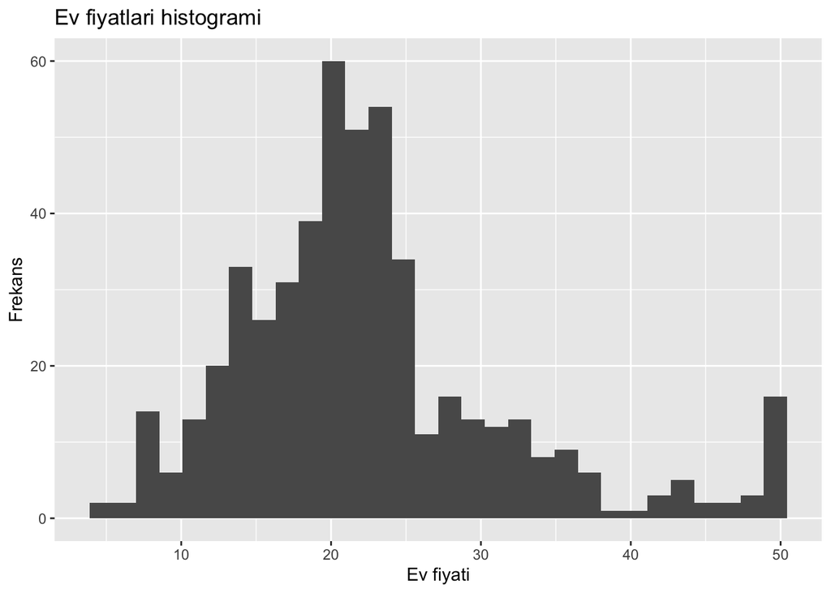

```r
library(ggplot2)
ggplot(data = boston, aes(x=medv)) +
  geom_histogram() +
  ggtitle(label = "Ev fiyatlari histogrami") +
  xlab("Ev fiyati") +
  ylab("Frekans")
```

Peki, şimdi `rm` değişkeni için aynı histogramı oluşturabilir misiniz?

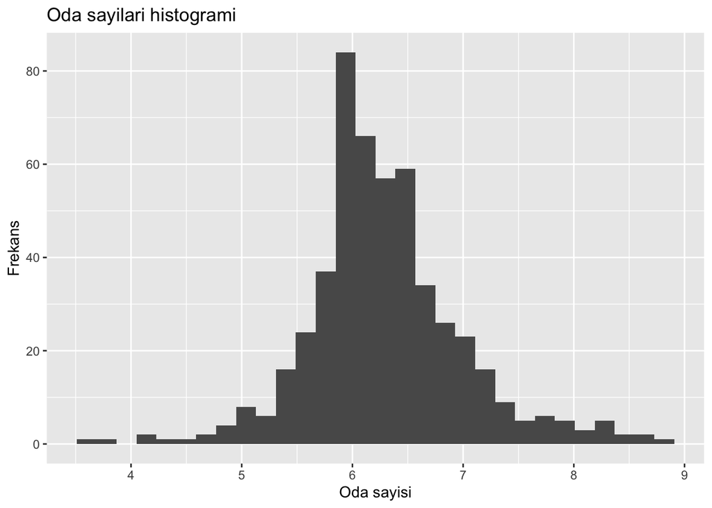

```r
ggplot(data = boston, aes(x=rm)) +
  geom_histogram() +
  ggtitle(label = "Oda sayilari histogrami") +
  xlab("Oda sayisi") +
  ylab("Frekans")
```

## 0.4 Soru 4: Kutu grafikleri

Yukarıdaki soruda bulunan `medv` ve `rm` değişkenleri için ayrı ayrı iki kutu grafiği oluşturunuz.

Öncelikle `medv` için:

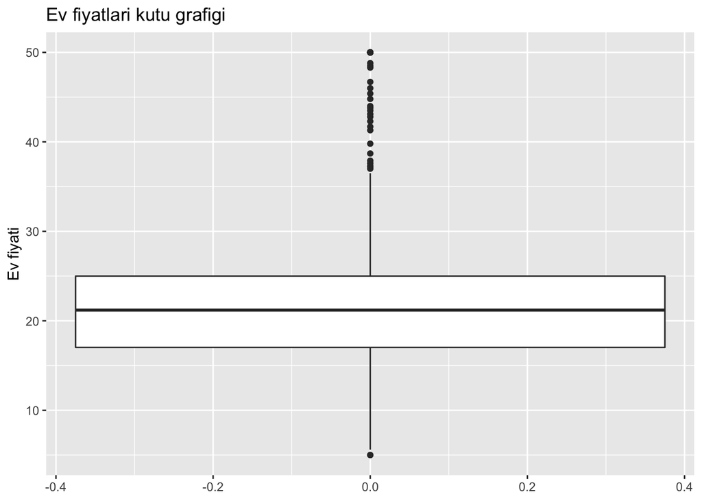

```r
ggplot(data = boston, aes(y=medv)) +
  geom_boxplot() +
  ggtitle(label = "Ev fiyatlari kutu grafigi") +
  ylab("Ev fiyati")
```

Şimdi de `rm`` için:

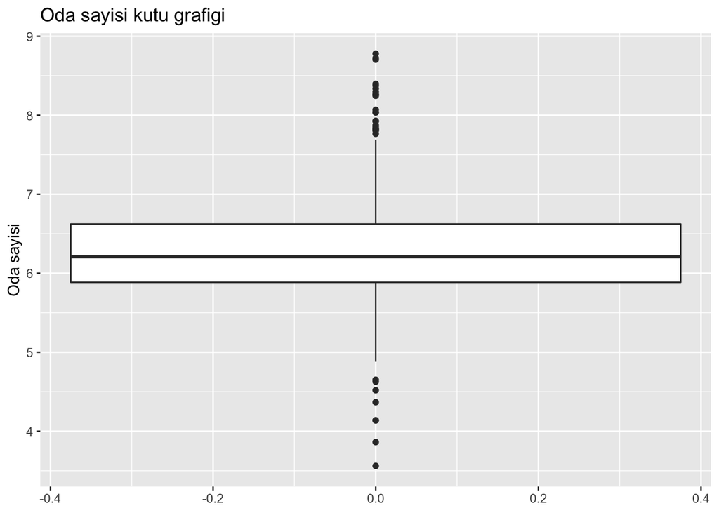

```r
ggplot(data = boston, aes(y=rm)) +
  geom_boxplot() +
  ggtitle(label = "Oda sayisi kutu grafigi") +
  ylab("Oda sayisi")
```

## 0.5 Soru 5: İki ekseni birlikte kullanma

Ortalama ev değerleri, Charles nehrine yakınında veya uzağında nasıl değişiyor? Aşağıdaki kutu grafiğini oluşturacak kodu yazabilir misiniz?

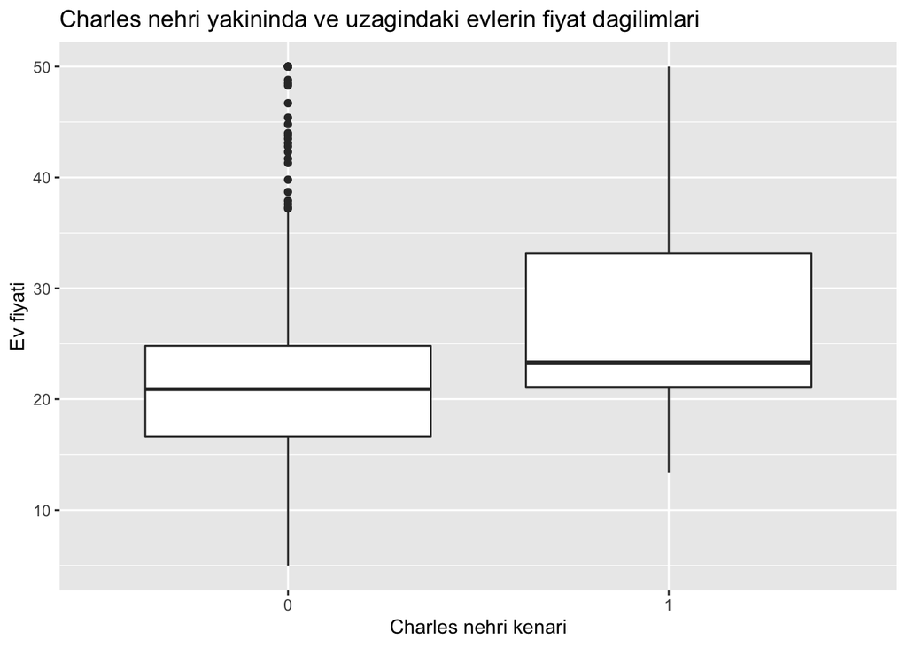

```r
ggplot(data = boston, aes(x=chas,y=medv)) +
  geom_boxplot() +
  ggtitle(label = "Charles nehri yakininda ve uzagindaki evlerin fiyat dagilimlari") +
  xlab("Charles nehri kenari") +
  ylab("Ev fiyati")
```

## 0.6 Soru 6: Ev fiyatları hangi değişkenlerden etkilenebilir?

Bir araştırmacı, ev fiyatlarının farklı değişkenlerle bağlı olan değişimini incelemek istiyor. Bu amaçla iki farklı grafik tasarlıyor:

- `medv` ve `lstat` değişkenleri arasındaki ilişki
- `medv` ve `rm` değişkenleri arasındaki ilişki

Ev fiyatları ve düşük sosyoekonomik seviye arasındaki ilişkiyi gösteren nokta grafiğini oluşturabilir misiniz? (y ekseni `medv`, x ekseni `lstat`)

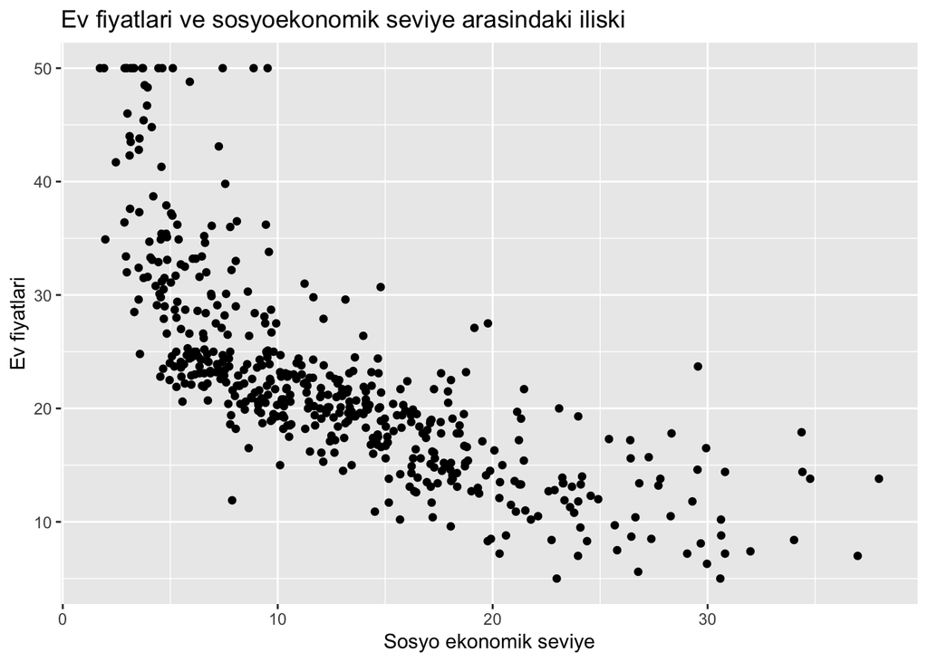

```r
ggplot(data = boston, aes(x = lstat, y = medv)) +
  geom_point() +
  ggtitle(label = "Ev fiyatlari ve sosyoekonomik seviye arasindaki iliski") +
  xlab("Sosyo ekonomik seviye") +
  ylab("Ev fiyatlari")
```

Sizce bu iki değişken arasında nasıl bir ikişki var? Bir cümleyle açıklayabilir misiniz? Cevabınızı aşağıdaki > ile başkaya satırlara yazınız:

> Grafiğe bakıldığında; ev fiyatları ile mahallelerdeki sosyo ekonomik seviye arasında bir ilişki var. Bir mahallede düşük sosyoekonomik seviyeye sahip ev miktarı arttıkça, o mahalledeki ev fiyatlarında bir azalış gözleniyor.

Peki ev fiyatları ve mahalledeki ortalama oda sayısı arasındaki ilişkiyi açıklayan grafiği oluşturabilir misiniz?

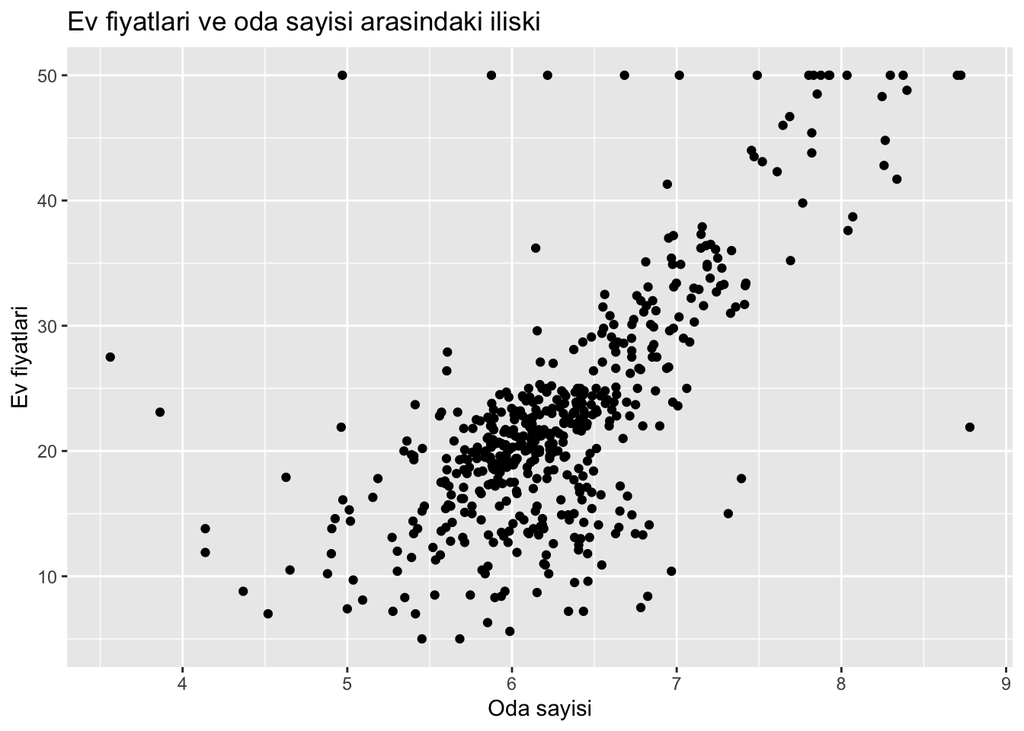

```r
ggplot(data = boston, aes(x = rm, y = medv)) +
  geom_point() +
  ggtitle(label = "Ev fiyatlari ve oda sayisi arasindaki iliski") +
  xlab("Oda sayisi") +
  ylab("Ev fiyatlari")
```

Grafiğe baktığınızda, oda sayısı ve ev fiyatları arasında nasıl bir ilişki var? Bir kaç cümleyle aşağıya açıklayabilir misiniz?

> Ev fiyatları ve o mahalledeki evlerde bulunan ortalama oda sayısı birbiri ile ilişkide. Mahalledeki ortalama oda sayısı arttıkça, ev fiyatları da artış gösteriyor.